# nnh6_stats1341_Final

Nnh6

2022-12-12

There are some methods that are “muted” but show my earlier thought process and the foundation to the final methods used.

#Set Up Download Libraries to use.

```r
library(tidyverse)
```

```r
library(ggplot2)
library( plyr )
```

##Data Collection & Data Cleaning Iterate through all the csv files and concatenate them together into the same df. (Combine multiple data sets) Note: All the csv files need to be in the same folder as this R markdown file to be loaded.

```r
final_scores_complete <- ldply( .data = list.files(pattern="*.csv"),
                    .fun = read.csv,
                    header = TRUE)
```

Removing extraneous variables Doing this by creating a new data frame that is a subset of the original one containing only the columns I need.

```r
keep <- c("Winner.tie", "Loser.tie", "PtsW", "PtsL")
final_scores_sub <- final_scores_complete[keep]
```

I will be adding in the seasons by extracting the years and months from the date variable to use for filtering later.

```r
final_scores_sub$year <- substr(final_scores_complete$Date,1,4)

final_scores_sub$month <- substr(final_scores_complete$Date,6,7)
```

For the Bradley-Terry Model, I will need to determine which team is the home team. I ended up not using the model.

Creating a Data frame of active NFL team names for filtering later.

```r
active_teams <- read.csv("active_nfl_teams.csv", TRUE, ",")
glimpse(active_teams)
```

```
## Rows: 32
## Columns: 2
## $ active_team_name <chr> "Arizona Cardinals", "Atlanta Falcons", "Carolina Pan…
## $ conference       <chr> "nfc", "nfc", "nfc", "nfc", "nfc", "nfc", "nfc", "nfc…
```

#Remove incomplete observations

Checking for any missing observations

Since I was able to determine that there were Incomplete observations (containing NA value), I will remove them.

Removing incomplete observations

```r
final_scores <- na.omit(final_scores_sub)
```

#Read in data for: Pythagorean Win Percentages

This disabled chunk is the initial start to finding the Pythagorean Win Percentage for the Detroit Lions alone. It goes through all Detroit Lions games in history. It collects how many games allowed, and how many points gotten.

However, since I wanted to compare the Detroit Lions to the rest of the NFL league, I will need to take a different approach.

##Setting up the Data: Whole NFL History

#Over Whole NFL History, all teams

Initializing a data frame to keep track of values.

```r
pwp_df_whole <- data.frame(matrix(ncol = 6, nrow = 0))

colnames(pwp_df_whole) <- c('team_name', 'pts_scored', 'pts_allowed', 'total_wins', 'total_losses', 'total_games')
```

These are the loops that collects and sorts the values needed to calculate the Pythagorean Win Percentages. I initially tried to run it in such a way where I would only need to go through one run over the data but it was having issues so I set them into 2 different loops.

Loop through Winners.

```r
for(i in 1:nrow(final_scores)) {       # for-loop over rows
    #once for winner
  if(sum(str_detect(pwp_df_whole$team_name, final_scores$Winner.tie[i])) <= 0){ #if this team is not already in the dataframe add them into a new row
   pwp_df_whole[nrow(pwp_df_whole) + 1,] <- c(final_scores$Winner.tie[i], final_scores$PtsW[i], final_scores$PtsL[i], 1, 0, 1)

  } else { #case if team is already in thepwp_df_whole

    #get the row index of the team name
    #possible alternate method: which(grepl(12345, df$colname))
    index = which(pwp_df_whole$team_name == final_scores$Winner.tie[i])

    #adjust points scored
   pwp_df_whole[index, 2] = strtoi(pwp_df_whole[index, 2]) + final_scores$PtsW[i]

    #adjust points allowed
   pwp_df_whole[index, 3] = strtoi(pwp_df_whole[index, 3]) + final_scores$PtsL[i]

    #adjusting total wins
   pwp_df_whole[index, 4] = strtoi(pwp_df_whole[index, 4]) + 1

    #adjust games total games
   pwp_df_whole[index, 6] = strtoi(pwp_df_whole[index, 6]) + 1
  }
}
```

Loop through Losers

```r
for(i in 1:nrow(final_scores)) {

    #once for the loser
  if(sum(str_detect(pwp_df_whole$team_name, final_scores$Loser.tie[i])) <= 0){ #if this team is not already in the dataframe add them into a new row
   pwp_df_whole[nrow(pwp_df_whole) + 1,] <- c(final_scores$Loser.tie[i], final_scores$PtsL[i], final_scores$PtsW[i], 0, 1, 1)

  } else { #case if team is already in thepwp_df_whole

    #get the row index of the team name
    #possible alternate method: which(grepl(12345, df$colname))
    index = which(pwp_df_whole$team_name == final_scores$Loser.tie[i])

    #adjust points scored
   pwp_df_whole[index, 2] = strtoi(pwp_df_whole[index, 2]) + final_scores$PtsL[i]

    #adjust points allowed
   pwp_df_whole[index, 3] = strtoi(pwp_df_whole[index, 3]) + final_scores$PtsW[i]

    #adjust games total losses
   pwp_df_whole[index, 5] = strtoi(pwp_df_whole[index, 5]) + 1

    #adjust games total games
   pwp_df_whole[index, 6] = strtoi(pwp_df_whole[index, 6]) + 1
  }


  #if there is a tie, we will treat it the same.
}
```

#For whole NFL history, only currently active teams Removing inactive teams. Only Currently Active teams’ Whole History

```r
pwp_df_whole_active <- data.frame(matrix(ncol = 6, nrow = 0))

colnames(pwp_df_whole_active) <- c('team_name', 'pts_scored', 'pts_allowed', 'total_wins', 'total_losses', 'total_games')

for(i in 1:nrow(pwp_df_whole)) {

  if(any(active_teams==pwp_df_whole$team_name[i])){
    #if the team name is contained in the active name list, add that row into the new data frame

    pwp_df_whole_active[nrow(pwp_df_whole_active) + 1,] <- c(pwp_df_whole$team_name[i], pwp_df_whole$pts_scored[i], pwp_df_whole$pts_allowed[i], pwp_df_whole$total_wins[i], pwp_df_whole$total_losses[i], pwp_df_whole$total_games[i])

  }
}
```

```r
#for all teams
pwp_df_whole$actual_wp <- strtoi(pwp_df_whole$total_wins) / (strtoi(pwp_df_whole$total_wins) + strtoi(pwp_df_whole$total_losses))

#for only currently active teams
pwp_df_whole_active$actual_wp <- strtoi(pwp_df_whole_active$total_wins) / (strtoi(pwp_df_whole_active$total_wins) + strtoi(pwp_df_whole_active$total_losses))
```

##Setting up the Data: only Post Super Bowl NFL History

Same as earlier but with a new condition of only retaining records from after the 1966-1967 first ever Super Bowl season.

```r
final_scores_sub$psb <- ifelse(strtoi(substr(final_scores_complete$Date,1,4)) >= 1966 & strtoi(substr(final_scores_complete$Date,6,7)) >= 5,substr(final_scores_complete$Date,1,4), NA)
#After Summer 1966 because it's the season leading up to the first superbowl in Jan 1967

final_scores_sub <- na.omit(final_scores_sub)
```

#All NFL teams since 1967 Super Bowl Season

Initializing a data frame to keep track of values.

```r
pwp_df_psb <- data.frame(matrix(ncol = 6, nrow = 0))

colnames(pwp_df_psb) <- c('team_name', 'pts_scored', 'pts_allowed', 'total_wins', 'total_losses', 'total_games')
```

Loop through Winners.

```r
for(i in 1:nrow(final_scores_sub)) {       # for-loop over rows
    #once for winner
  if(sum(str_detect(pwp_df_psb$team_name, final_scores_sub$Winner.tie[i])) <= 0){ #if this team is not already in the dataframe add them into a new row
   pwp_df_psb[nrow(pwp_df_psb) + 1,] <- c(final_scores_sub$Winner.tie[i], final_scores_sub$PtsW[i], final_scores_sub$PtsL[i], 1, 0, 1)

  } else { #case if team is already in thepwp_df_psb

    #get the row index of the team name
    #possible alternate method: which(grepl(12345, df$colname))
    index = which(pwp_df_psb$team_name == final_scores_sub$Winner.tie[i])

    #adjust points scored
   pwp_df_psb[index, 2] = strtoi(pwp_df_psb[index, 2]) + final_scores_sub$PtsW[i]

    #adjust points allowed
   pwp_df_psb[index, 3] = strtoi(pwp_df_psb[index, 3]) + final_scores_sub$PtsL[i]

    #adjusting total wins
   pwp_df_psb[index, 4] = strtoi(pwp_df_psb[index, 4]) + 1

    #adjust games total games
   pwp_df_psb[index, 6] = strtoi(pwp_df_psb[index, 6]) + 1
  }
}
```

Loop through Losers

```r
for(i in 1:nrow(final_scores_sub)) {

    #once for the loser
  if(sum(str_detect(pwp_df_psb$team_name, final_scores_sub$Loser.tie[i])) <= 0){ #if this team is not already in the dataframe add them into a new row
   pwp_df_psb[nrow(pwp_df_psb) + 1,] <- c(final_scores_sub$Loser.tie[i], final_scores_sub$PtsL[i], final_scores_sub$PtsW[i], 0, 1, 1)

  } else { #case if team is already in thepwp_df_psb

    #get the row index of the team name
    #possible alternate method: which(grepl(12345, df$colname))
    index = which(pwp_df_psb$team_name == final_scores_sub$Loser.tie[i])

    #adjust points scored
   pwp_df_psb[index, 2] = strtoi(pwp_df_psb[index, 2]) + final_scores_sub$PtsL[i]

    #adjust points allowed
   pwp_df_psb[index, 3] = strtoi(pwp_df_psb[index, 3]) + final_scores_sub$PtsW[i]

    #adjust games total losses
   pwp_df_psb[index, 5] = strtoi(pwp_df_psb[index, 5]) + 1

    #adjust games total games
   pwp_df_psb[index, 6] = strtoi(pwp_df_psb[index, 6]) + 1
  }

  #if there is a tie, we will treat it the same.
}
```

#Only currently active NFL teams since 1967 Super Bowl Season

```r
pwp_df_psb_active <- data.frame(matrix(ncol = 6, nrow = 0))

colnames(pwp_df_psb_active) <- c('team_name', 'pts_scored', 'pts_allowed', 'total_wins', 'total_losses', 'total_games')

for(i in 1:nrow(pwp_df_psb)) {

  if(any(active_teams==pwp_df_psb$team_name[i])){
    #if the team name is contained in the active name list, add that row into the new data frame

    pwp_df_psb_active[nrow(pwp_df_psb_active) + 1,] <- c(pwp_df_psb$team_name[i], pwp_df_psb$pts_scored[i], pwp_df_psb$pts_allowed[i], pwp_df_psb$total_wins[i], pwp_df_psb$total_losses[i], pwp_df_psb$total_games[i])

  }
}
```

```r
#for all teams
pwp_df_psb$actual_wp <- strtoi(pwp_df_psb$total_wins) / (strtoi(pwp_df_psb$total_wins) + strtoi(pwp_df_psb$total_losses))

#for currently active teams
pwp_df_psb_active$actual_wp <- strtoi(pwp_df_psb_active$total_wins) / (strtoi(pwp_df_psb_active$total_wins) + strtoi(pwp_df_psb_active$total_losses))
```

To prevent NaN from divisions by 0, remove any observations where both points scored and allowed are 0.

```r
pwp_df_whole <- pwp_df_whole[-which(pwp_df_whole$pts_scored == 0 & pwp_df_whole$pts_allowed == 0),]
```

##Descriptive Statistics: Pythagorean Win Percentages

Finding the Optimal Pythagorean Exponent. Code to calculate optimal Pythagorean coefficient (from Homework 7)

#Whole History, All Teams For whole

```r
# Initialize matrix to store exponents, increments, RMSEs, and correlations
results_whole = matrix(0, nrow = 0, ncol = 4)
colnames(results_whole) = c("exponent", "increment", "RMSE", "correlation")

# Initialize starting values for exponent, increment, and the best RMSE
exponent = 1
increment = 1
best_RMSE = 162

# Continue to find a better exponent until the amount we change the exponent by falls below 0.01
while(abs(increment) > 0.01) {
  # Save Pythagorean wins, calculate the error between actual and Pythagorean, and find the RMSE
  pyth_wins = strtoi(pwp_df_whole$total_games) * (strtoi(pwp_df_whole$pts_scored)^exponent / (strtoi(pwp_df_whole$pts_scored)^exponent + strtoi(pwp_df_whole$pts_allowed)^exponent))

  RMSE = sqrt(sum((strtoi(pwp_df_whole$total_wins) - pyth_wins)^2)/nrow(pwp_df_whole))

  # Save current exponent, increment, RMSE, and correlation for current iteration
  correlation = cor(strtoi(pwp_df_whole$total_wins)/strtoi(pwp_df_whole$total_games), pyth_wins/strtoi(pwp_df_whole$total_games))
  results_whole = rbind(results_whole, c(exponent, increment, RMSE, correlation))

  if(RMSE < best_RMSE) {  # If using current exponent gives us the best current RMSE, update RMSE and exponent
    best_RMSE = RMSE
    best_exponent = exponent
    exponent = exponent + increment  # Increment/decrement the exponent by some amount
  } else {  # If using current exponent gives us a worse RMSE, move in the other direction
    exponent = exponent - 1.5*increment
    increment = -0.5*increment
  }
}

results_whole  = data.frame(results_whole)
```

Checking results_whole

Finding the best exponent (the one with the lowest RMSE)

```r
results_whole[which(results_whole$RMSE == min(results_whole$RMSE), arr.ind = TRUE),]
```

```
##   exponent increment     RMSE correlation
## 9  2.21875  -0.03125 7.281147   0.8103574
```

Calculate PWP

```r
best_exponent = 2.21875 #lowest RMSE of 7.281147

#calculate the pythagorean winning percentage using points scored and points allowed
pwp_df_whole$pwp <- I(strtoi(pwp_df_whole$pts_scored)^best_exponent)/(I(strtoi(pwp_df_whole$pts_scored)^best_exponent) + I(strtoi(pwp_df_whole$pts_allowed)^best_exponent))

#calculate the error between actual and pythagorean win percentages
pwp_df_whole$error <- as.double(pwp_df_whole$actual_wp) - as.double(pwp_df_whole$pwp)
```

#Whole History, Active Teams

```r
# Initialize matrix to store exponents, increments, RMSEs, and correlations
results_whole_active = matrix(0, nrow = 0, ncol = 4)
colnames(results_whole_active) = c("exponent", "increment", "RMSE", "correlation")

# Initialize starting values for exponent, increment, and the best RMSE
exponent = 1
increment = 1
best_RMSE = 162

# Continue to find a better exponent until the amount we change the exponent by falls below 0.01
while(abs(increment) > 0.01) {
  # Save Pythagorean wins, calculate the error between actual and Pythagorean, and find the RMSE
  pyth_wins = strtoi(pwp_df_whole_active$total_games) * (strtoi(pwp_df_whole_active$pts_scored)^exponent / (strtoi(pwp_df_whole_active$pts_scored)^exponent + strtoi(pwp_df_whole_active$pts_allowed)^exponent))
  RMSE = sqrt(sum((strtoi(pwp_df_whole_active$total_wins) - pyth_wins)^2)/nrow(pwp_df_whole_active))

  # Save current exponent, increment, RMSE, and correlation for current iteration
  correlation = cor(strtoi(pwp_df_whole_active$total_wins)/strtoi(pwp_df_whole_active$total_games), pyth_wins/strtoi(pwp_df_whole_active$total_games))
  results_whole_active = rbind(results_whole_active, c(exponent, increment, RMSE, correlation))

  if(RMSE < best_RMSE) {  # If using current exponent gives us the best current RMSE, update RMSE and exponent
    best_RMSE = RMSE
    best_exponent = exponent
    exponent = exponent + increment  # Increment/decrement the exponent by some amount
  } else {  # If using current exponent gives us a worse RMSE, move in the other direction
    exponent = exponent - 1.5*increment
    increment = -0.5*increment
  }
}

results_whole_active  = data.frame(results_whole_active)
```

Checking results_whole_active

Finding the best exponent (the one with the lowest RMSE)

```r
results_whole_active[which(results_whole_active$RMSE == min(results_whole_active$RMSE), arr.ind = TRUE),]
```

```
##    exponent increment     RMSE correlation
## 10  2.28125  -0.03125 12.54606   0.8717401
```

Calculate PWP

```r
best_exponent = 2.28125 #lowest RMSE of 12.54606

#calculate the pythagorean winning percentage using points scored and points allowed
pwp_df_whole_active$pwp <- I(strtoi(pwp_df_whole_active$pts_scored)^best_exponent)/(I(strtoi(pwp_df_whole_active$pts_scored)^best_exponent) + I(strtoi(pwp_df_whole_active$pts_allowed)^best_exponent))

#calculate the error between actual and pythagorean win percentages
pwp_df_whole_active$error <- as.double(pwp_df_whole_active$actual_wp) - as.double(pwp_df_whole_active$pwp)
```

#Post Super Bowl, All Teams

```r
# Initialize matrix to store exponents, increments, RMSEs, and correlations
results_psb = matrix(0, nrow = 0, ncol = 4)
colnames(results_psb) = c("exponent", "increment", "RMSE", "correlation")

# Initialize starting values for exponent, increment, and the best RMSE
exponent = 1
increment = 1
best_RMSE = 162

# Continue to find a better exponent until the amount we change the exponent by falls below 0.01
while(abs(increment) > 0.01) {
  # Save Pythagorean wins, calculate the error between actual and Pythagorean, and find the RMSE
  pyth_wins = strtoi(pwp_df_psb$total_games) * (strtoi(pwp_df_psb$pts_scored)^exponent / (strtoi(pwp_df_psb$pts_scored)^exponent + strtoi(pwp_df_psb$pts_allowed)^exponent))
  RMSE = sqrt(sum((strtoi(pwp_df_psb$total_wins) - pyth_wins)^2)/nrow(pwp_df_psb))

  # Save current exponent, increment, RMSE, and correlation for current iteration
  correlation = cor(strtoi(pwp_df_psb$total_wins)/strtoi(pwp_df_psb$total_games), pyth_wins/strtoi(pwp_df_psb$total_games))
  results_psb = rbind(results_psb, c(exponent, increment, RMSE, correlation))

  if(RMSE < best_RMSE) {  # If using current exponent gives us the best current RMSE, update RMSE and exponent
    best_RMSE = RMSE
    best_exponent = exponent
    exponent = exponent + increment  # Increment/decrement the exponent by some amount
  } else {  # If using current exponent gives us a worse RMSE, move in the other direction
    exponent = exponent - 1.5*increment
    increment = -0.5*increment
  }
}

results_psb  = data.frame(results_psb)
```

Checking results_psb

Finding the best exponent (the one with the lowest RMSE)

```r
results_psb[which(results_psb$RMSE == min(results_psb$RMSE), arr.ind = TRUE),]
```

```
##   exponent increment     RMSE correlation
## 9    2.375    0.0625 7.544588   0.9178616
```

Calculate PWP

```r
best_exponent = 2.375 #lowest RMSE of 7.544588

#calculate the pythagorean winning percentage using points scored and points allowed
pwp_df_psb$pwp <- I(strtoi(pwp_df_psb$pts_scored)^best_exponent)/(I(strtoi(pwp_df_psb$pts_scored)^best_exponent) + I(strtoi(pwp_df_psb$pts_allowed)^best_exponent))

#calculate the error between actual and pythagorean win percentages
pwp_df_psb$error <- as.double(pwp_df_psb$actual_wp) - as.double(pwp_df_psb$pwp)
```

#Post Super Bowl, Active Teams For whole

```r
# Initialize matrix to store exponents, increments, RMSEs, and correlations
results_psb_active = matrix(0, nrow = 0, ncol = 4)
colnames(results_psb_active) = c("exponent", "increment", "RMSE", "correlation")

# Initialize starting values for exponent, increment, and the best RMSE
exponent = 1
increment = 1
best_RMSE = 162

# Continue to find a better exponent until the amount we change the exponent by falls below 0.01
while(abs(increment) > 0.01) {
  # Save Pythagorean wins, calculate the error between actual and Pythagorean, and find the RMSE
  pyth_wins = strtoi(pwp_df_psb_active$total_games) * (strtoi(pwp_df_psb_active$pts_scored)^exponent / (strtoi(pwp_df_psb_active$pts_scored)^exponent + strtoi(pwp_df_psb_active$pts_allowed)^exponent))
  RMSE = sqrt(sum((strtoi(pwp_df_psb_active$total_wins) - pyth_wins)^2)/nrow(pwp_df_psb_active))

  # Save current exponent, increment, RMSE, and correlation for current iteration
  correlation = cor(strtoi(pwp_df_psb_active$total_wins)/strtoi(pwp_df_psb_active$total_games), pyth_wins/strtoi(pwp_df_psb_active$total_games))
  results_psb_active = rbind(results_psb_active, c(exponent, increment, RMSE, correlation))

  if(RMSE < best_RMSE) {  # If using current exponent gives us the best current RMSE, update RMSE and exponent
    best_RMSE = RMSE
    best_exponent = exponent
    exponent = exponent + increment  # Increment/decrement the exponent by some amount
  } else {  # If using current exponent gives us a worse RMSE, move in the other direction
    exponent = exponent - 1.5*increment
    increment = -0.5*increment
  }
}

results_psb_active  = data.frame(results_psb_active)
```

Checking results_psb_active

Finding the best exponent (the one with the lowest RMSE)

```r
results_psb_active[which(results_psb_active$RMSE == min(results_psb_active$RMSE), arr.ind = TRUE),]
```

```
##   exponent increment     RMSE correlation
## 9    2.375    0.0625 7.864212   0.8869167
```

Calculate PWP

```r
best_exponent = 2.375 #lowest RMSE of 7.864212

#calculate the pythagorean winning percentage using points scored and points allowed
pwp_df_psb_active$pwp <- I(strtoi(pwp_df_psb_active$pts_scored)^best_exponent)/(I(strtoi(pwp_df_psb_active$pts_scored)^best_exponent) + I(strtoi(pwp_df_psb_active$pts_allowed)^best_exponent))

#calculate the error between actual and pythagorean win percentages
pwp_df_psb_active$error <- as.double(pwp_df_psb_active$actual_wp) - as.double(pwp_df_psb_active$pwp)
```

#Bradley-Terry Models Exploring the possibility of using this model on this data.

This data set has many ties which means this model won’t work at it’s best. (About 2% of the data are ties…)

```r
sum(count(which(final_scores$PtsW == final_scores$PtsL))$freq)
```

```
## [1] 319
```

```r
sum(count(which(final_scores$PtsW == final_scores$PtsL))$freq)/nrow(final_scores)
```

```
## [1] 0.01895425
```

For simplicity and clarity, removing inactive teams.

```r
btm_df_active <- data.frame(matrix(ncol = 6, nrow = 0))

colnames(btm_df_active) <- c('team_name', 'pts_scored', 'pts_allowed', 'total_wins', 'total_losses', 'total_games')

for(i in 1:nrow(pwp_df_whole)) {

  if(any(active_teams==pwp_df_whole$team_name[i])){
    #if the team name is contained in the active name list, add that row into the new data frame

     btm_df_active[nrow(btm_df_active) + 1,] <- c(pwp_df_whole$team_name[i], pwp_df_whole$pts_scored[i], pwp_df_whole$pts_allowed[i], pwp_df_whole$total_wins[i], pwp_df_whole$total_losses[i], pwp_df_whole$total_games[i])

  }
}
```

The scores seem pretty normal.

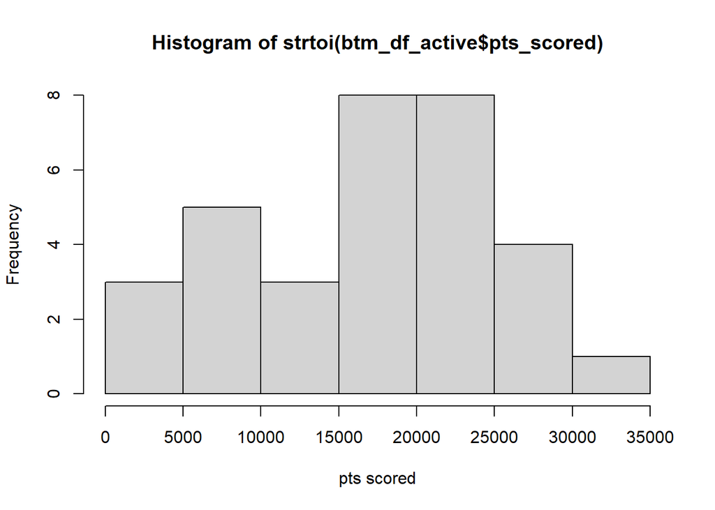

```r
#create a histogram
hist(strtoi(btm_df_active$pts_scored), xlab = "pts scored", breaks = 10)
```

At this point, I realized that a Bradley-Terry Model may not be the best approach to answering the focus question.

##Exploring the data Focusing on the 4 different Pythagorean Win Percentages. Let’s make different graphs to see what I can learn from them

#Histograms

Distribution of Total Games

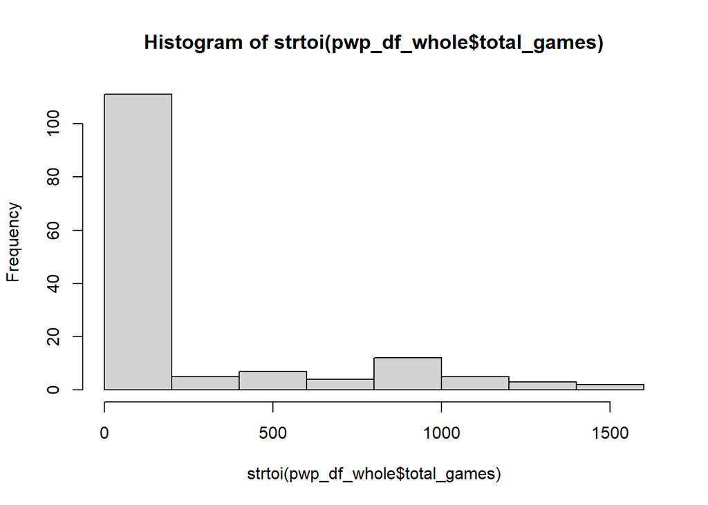

```r
hist(strtoi(pwp_df_whole$total_games))
```

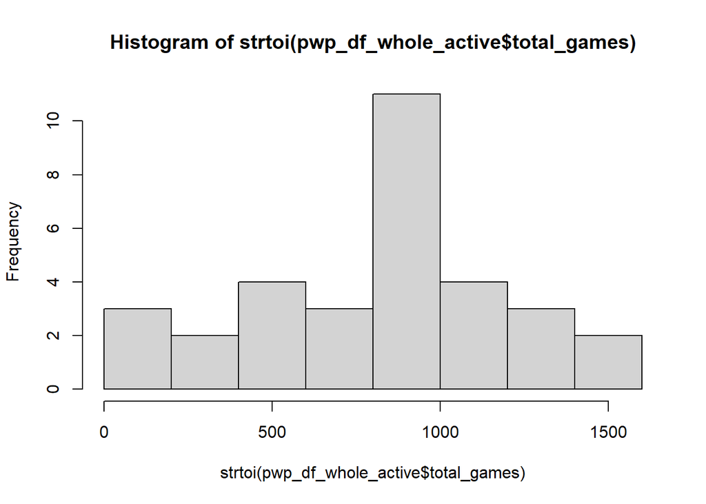

```r
hist(strtoi(pwp_df_whole_active$total_games))
```

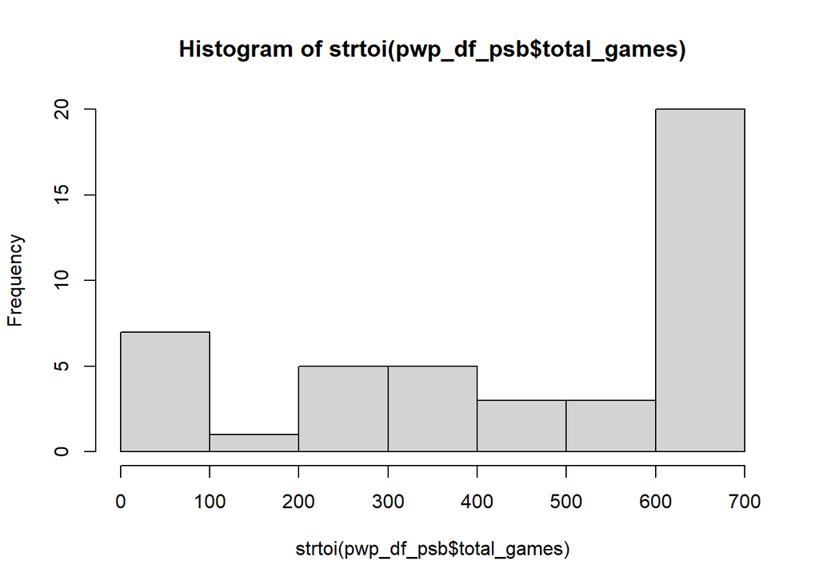

```r
hist(strtoi(pwp_df_psb$total_games))
```

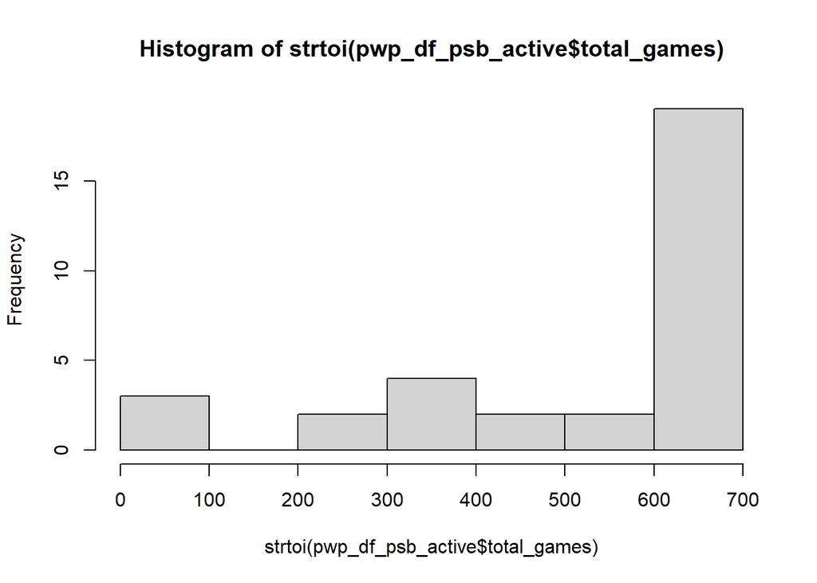

```r
hist(strtoi(pwp_df_psb_active$total_games))
```

Distribution of Points Scored

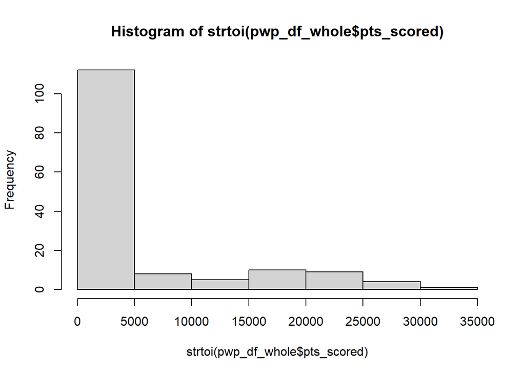

```r
hist(strtoi(pwp_df_whole$pts_scored))
```

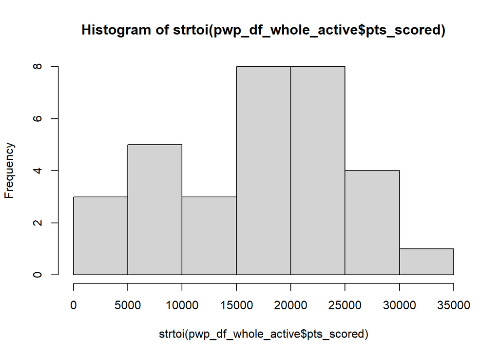

```r
hist(strtoi(pwp_df_whole_active$pts_scored))
```

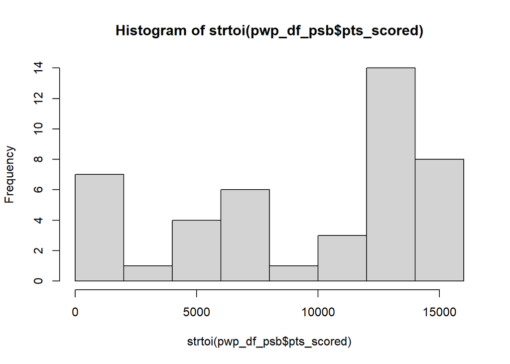

```r
hist(strtoi(pwp_df_psb$pts_scored))
```

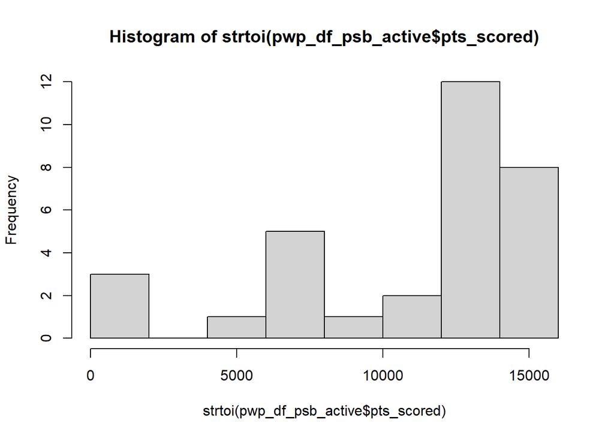

```r
hist(strtoi(pwp_df_psb_active$pts_scored))
```

Distribution of Points Allowed

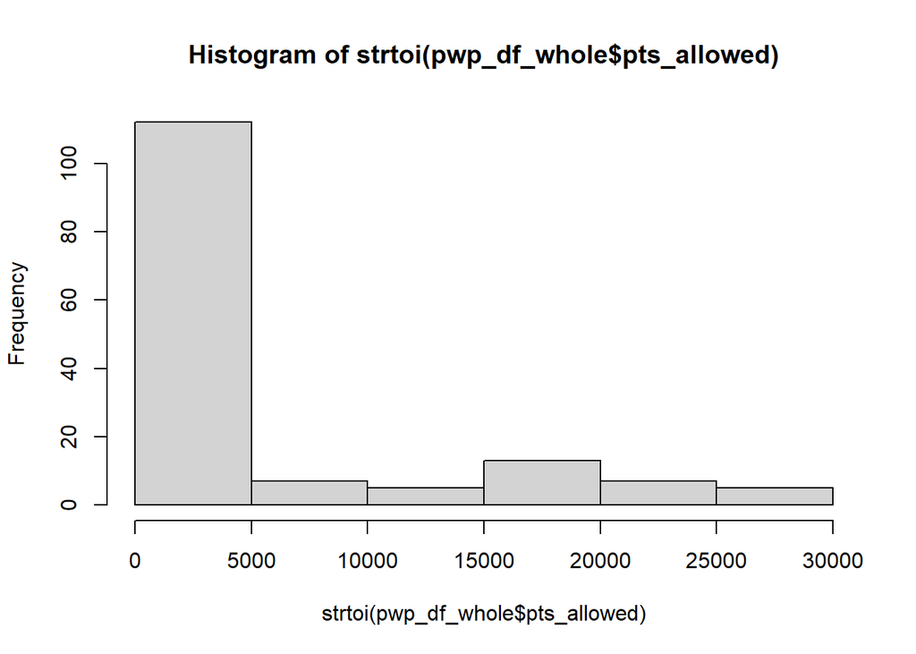

```r
hist(strtoi(pwp_df_whole$pts_allowed))
```

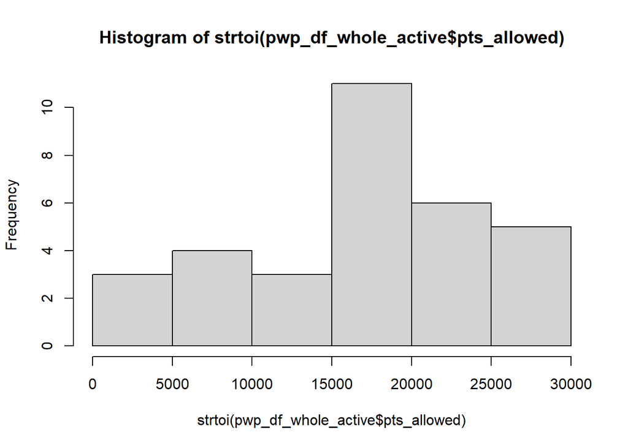

```r
hist(strtoi(pwp_df_whole_active$pts_allowed))
```

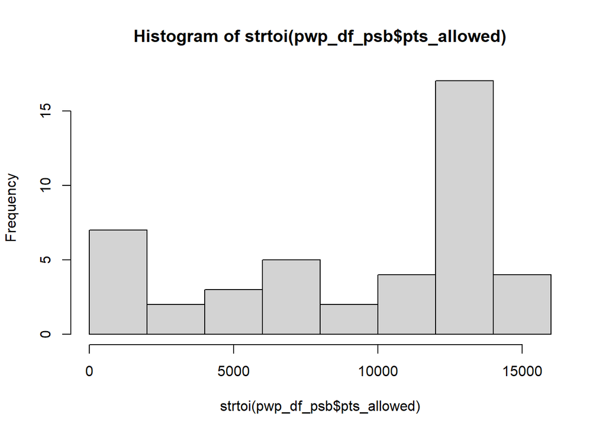

```r
hist(strtoi(pwp_df_psb$pts_allowed))
```

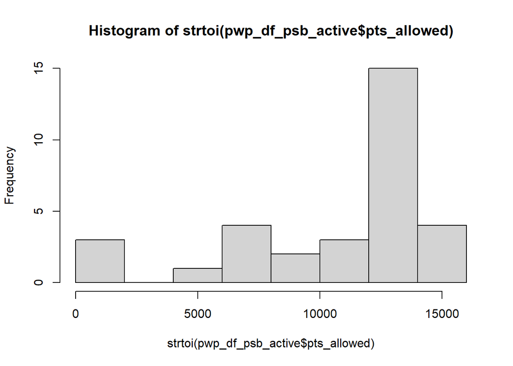

```r
hist(strtoi(pwp_df_psb_active$pts_allowed))
```

Distribution of Total Wins

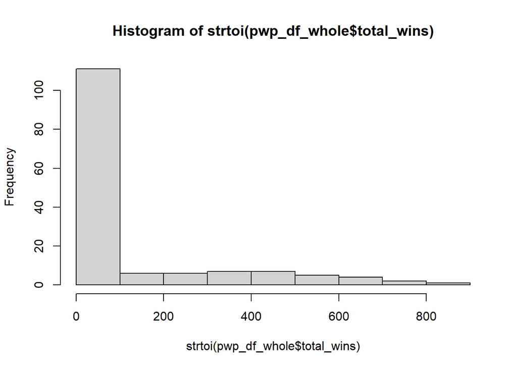

```r
hist(strtoi(pwp_df_whole$total_wins))
```

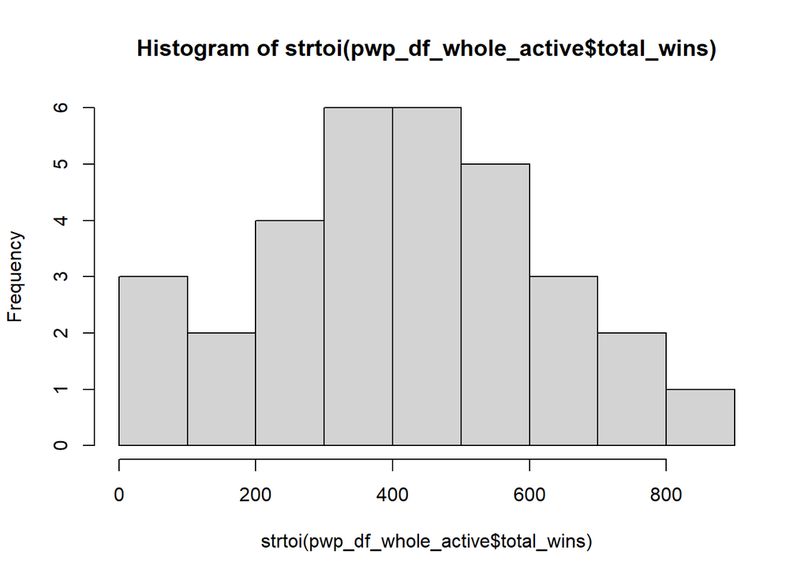

```r
hist(strtoi(pwp_df_whole_active$total_wins))
```

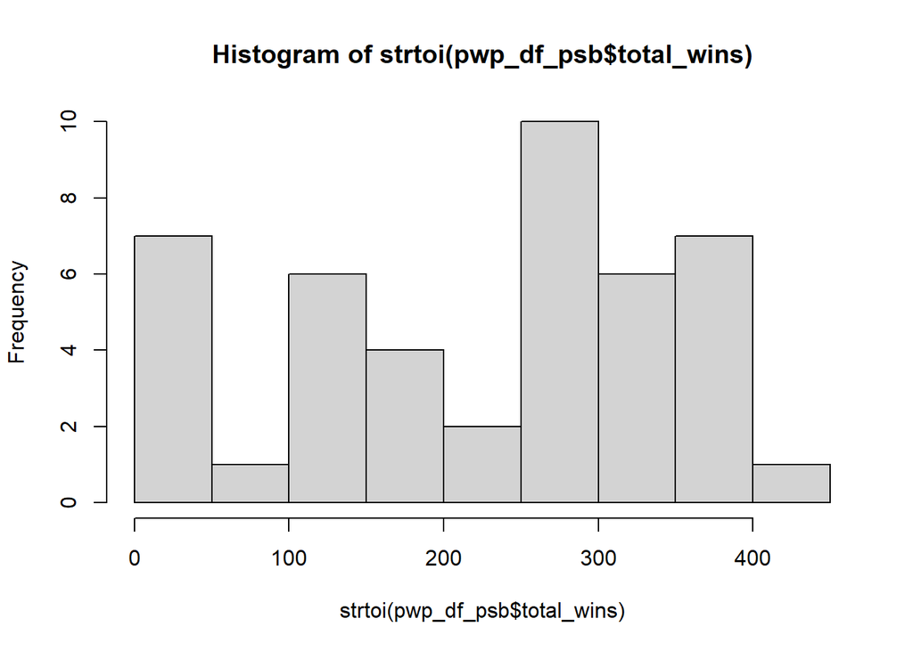

```r
hist(strtoi(pwp_df_psb$total_wins))
```

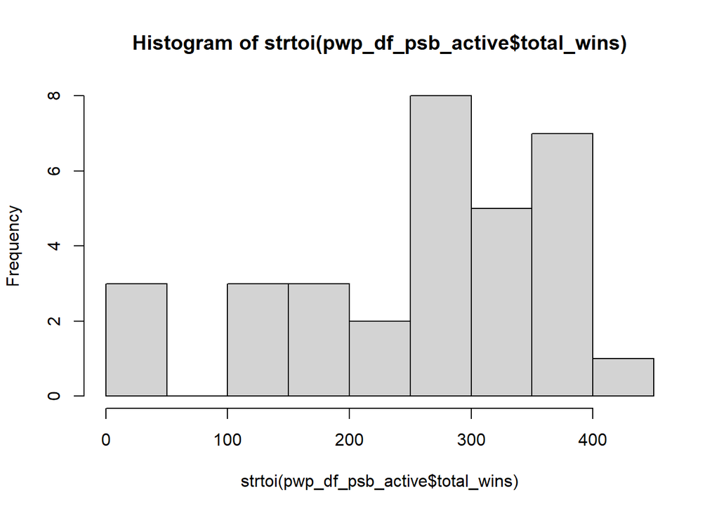

```r
hist(strtoi(pwp_df_psb_active$total_wins))
```

Distribution of Total Losses

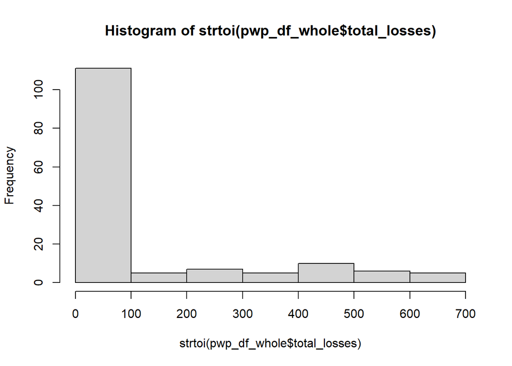

```r
hist(strtoi(pwp_df_whole$total_losses))
```

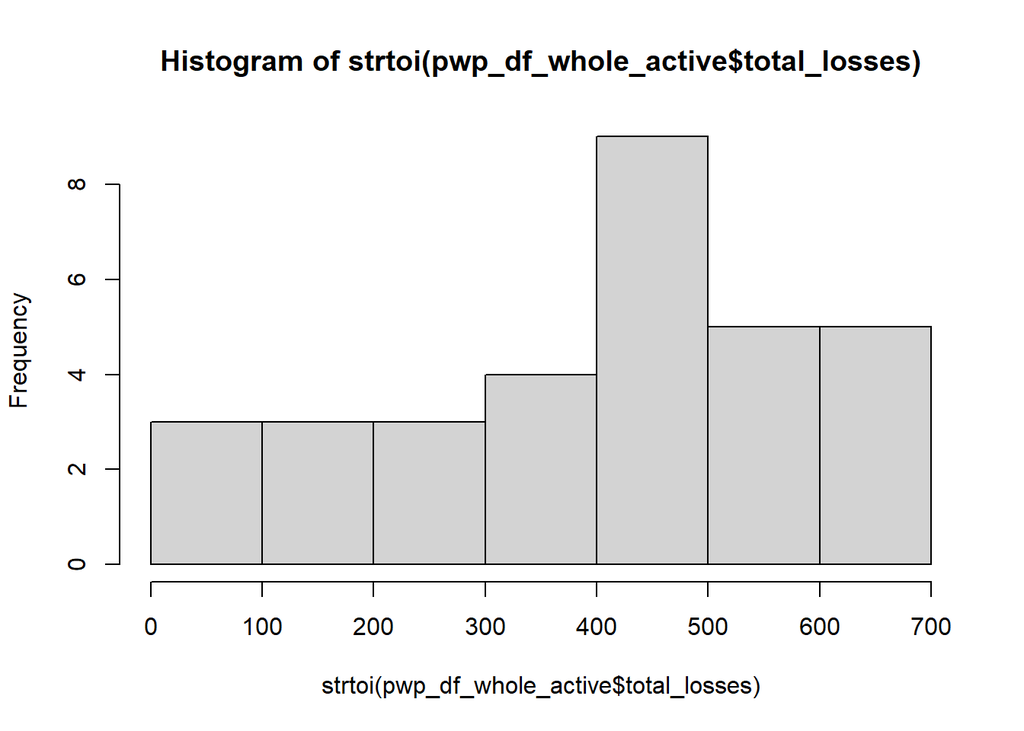

```r
hist(strtoi(pwp_df_whole_active$total_losses))
```

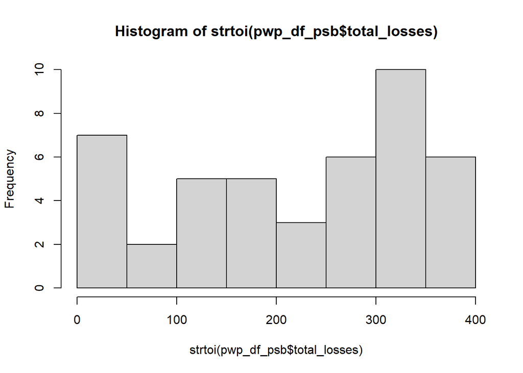

```r
hist(strtoi(pwp_df_psb$total_losses))
```

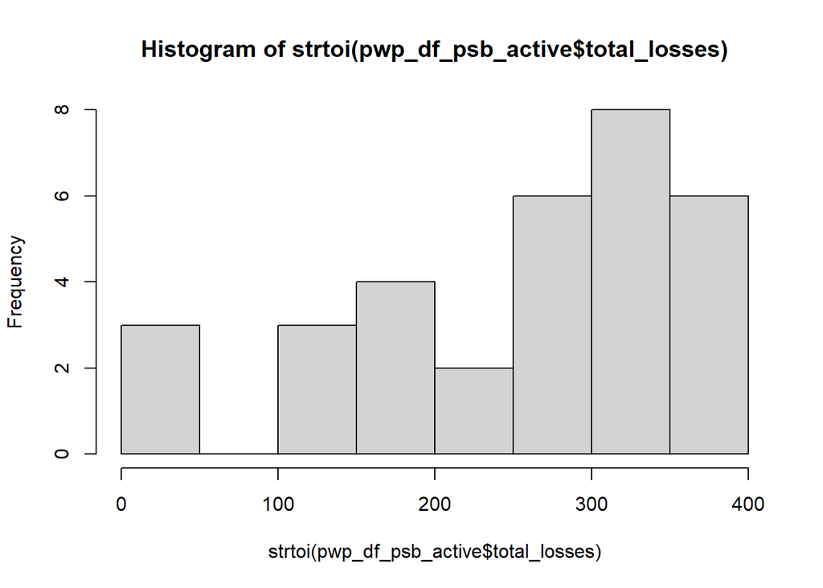

```r
hist(strtoi(pwp_df_psb_active$total_losses))
```

Distribution of Actual Win Percentages

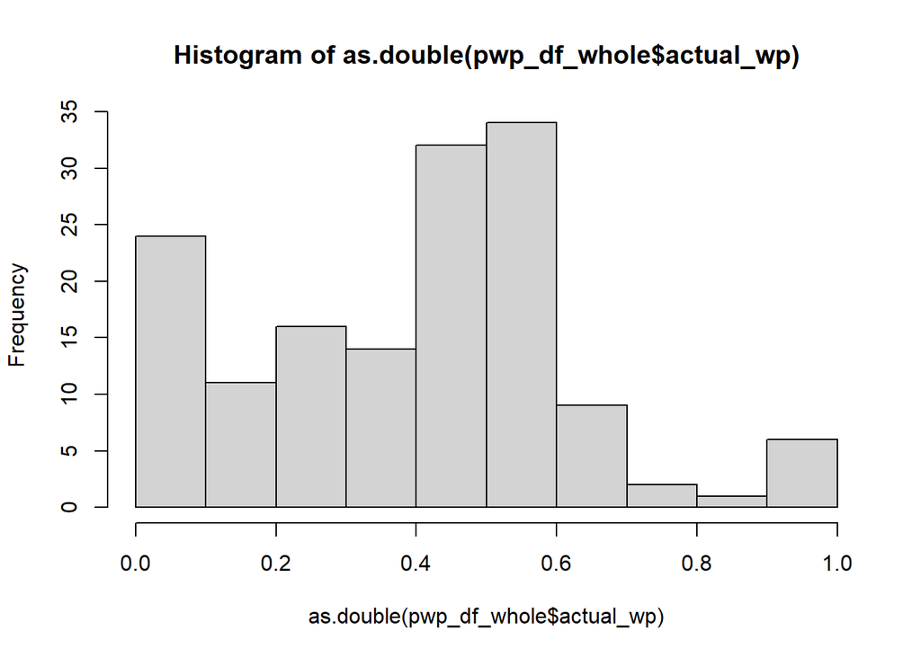

```r
hist(as.double(pwp_df_whole$actual_wp))
```

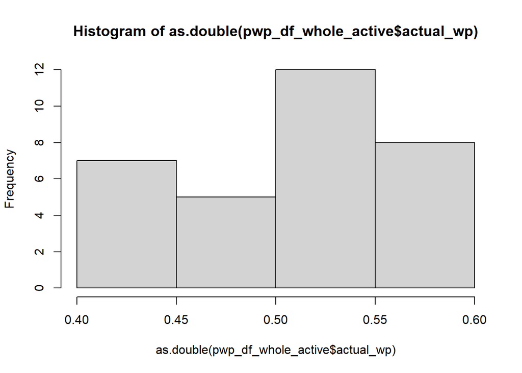

```r
hist(as.double(pwp_df_whole_active$actual_wp))
```

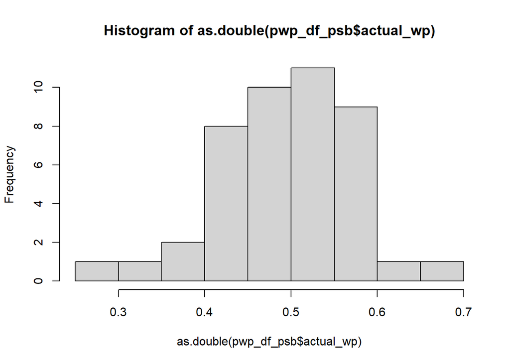

```r
hist(as.double(pwp_df_psb$actual_wp))
```

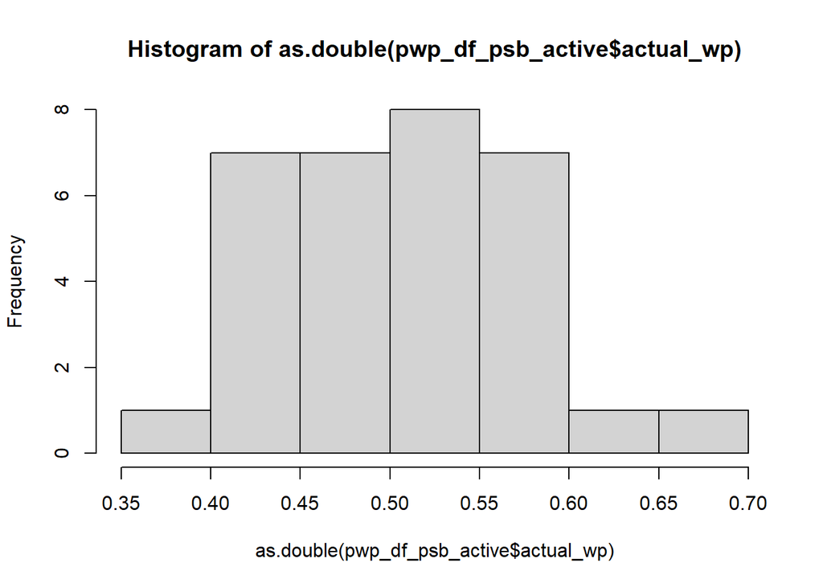

```r
hist(as.double(pwp_df_psb_active$actual_wp))
```

Distribution of PWP

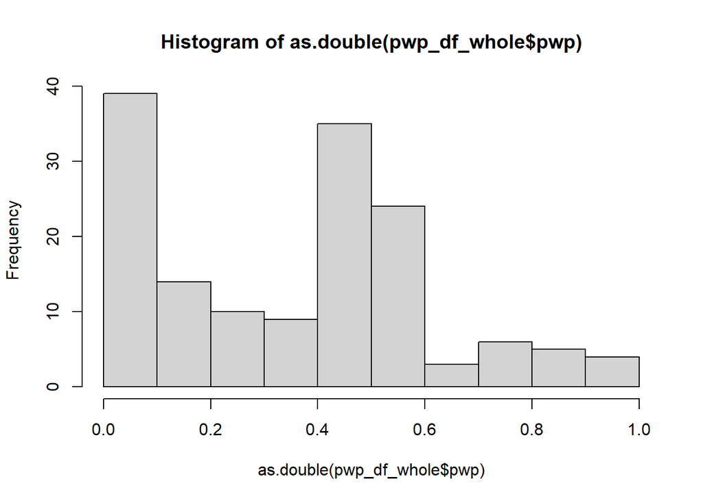

```r
#create a histogram of errors
hist(as.double(pwp_df_whole$pwp))
```

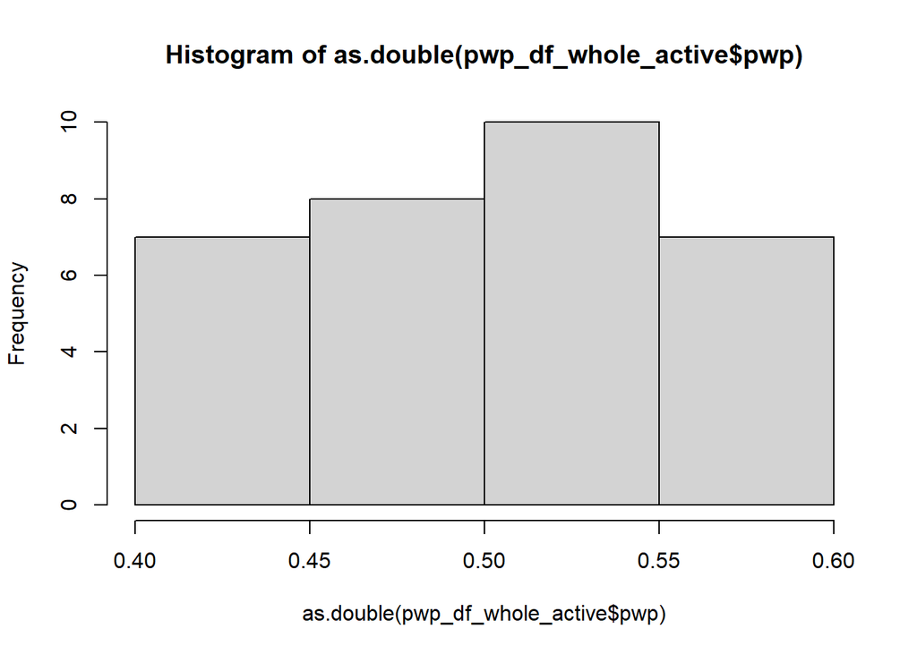

```r
hist(as.double(pwp_df_whole_active$pwp))
```

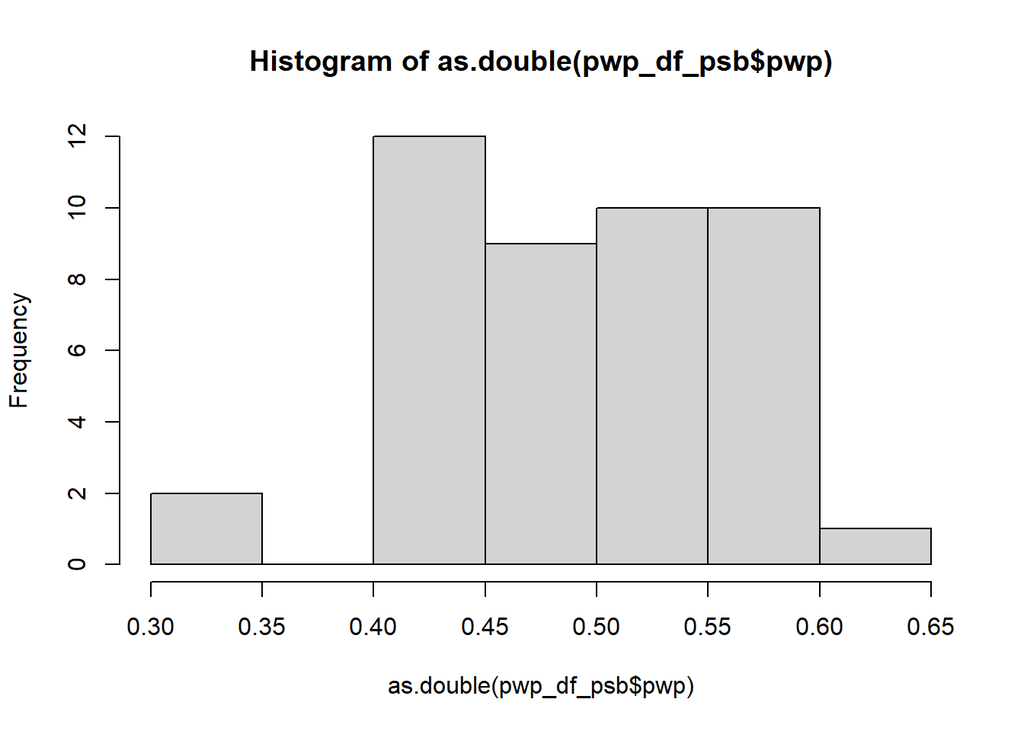

```r
hist(as.double(pwp_df_psb$pwp))
```

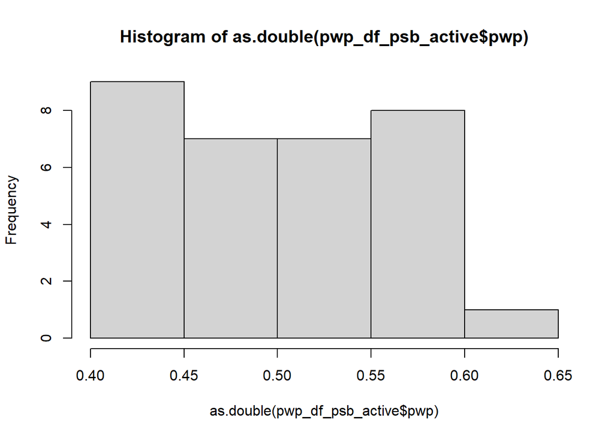

```r
hist(as.double(pwp_df_psb_active$pwp))
```

Distribution of Errors/Residuals

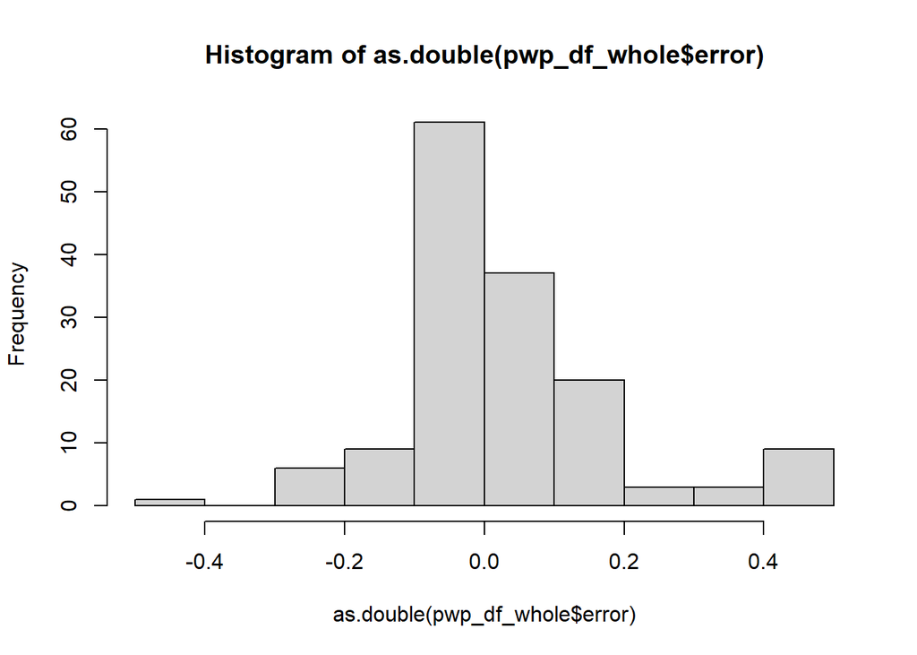

```r
#create a histogram of errors
hist(as.double(pwp_df_whole$error))
```

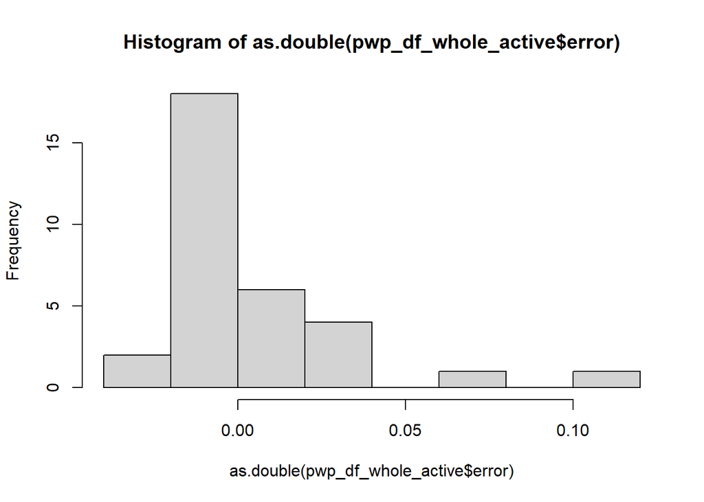

```r
hist(as.double(pwp_df_whole_active$error))
```

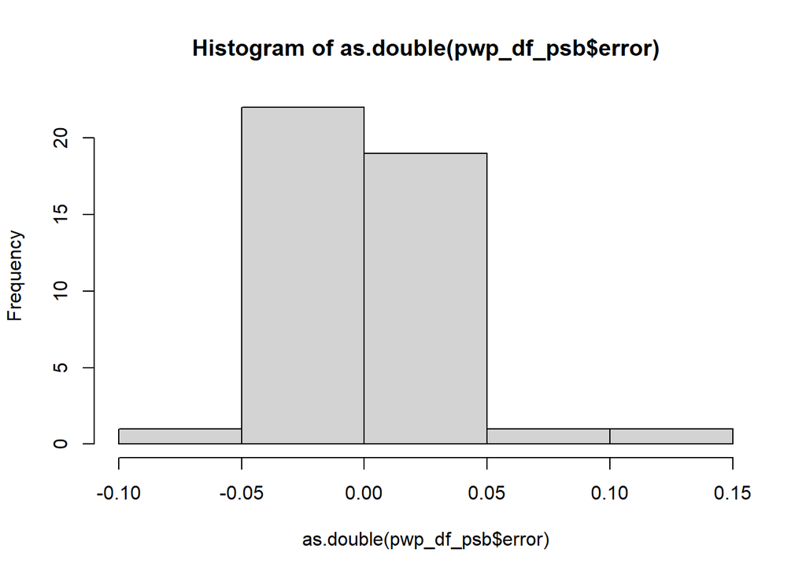

```r
hist(as.double(pwp_df_psb$error))
```

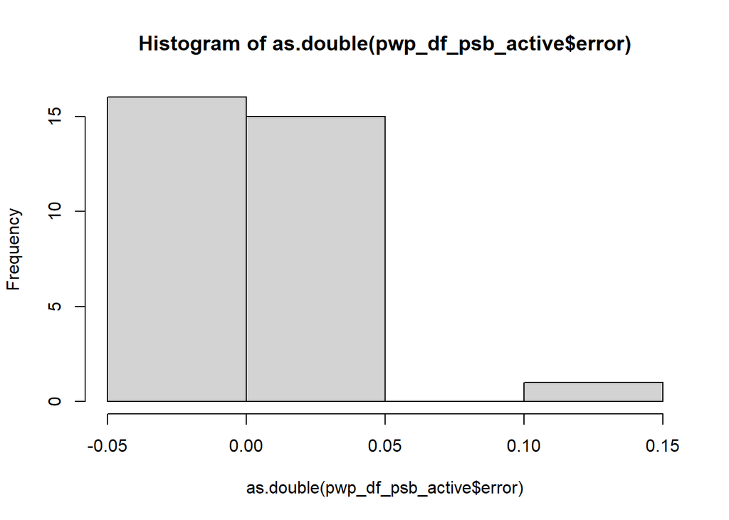

```r
hist(as.double(pwp_df_psb_active$error))
```

#Summaries

```r
#changing class types for summary
pwp_df_whole$pts_scored <- as.integer(pwp_df_whole$pts_scored)
pwp_df_whole$pts_allowed <- as.integer(pwp_df_whole$pts_allowed)
pwp_df_whole$total_wins <- as.integer(pwp_df_whole$total_wins)
pwp_df_whole$total_losses <- as.integer(pwp_df_whole$total_losses)
pwp_df_whole$total_games <- as.integer(pwp_df_whole$total_games)

summary(pwp_df_whole)
```

```
##   team_name           pts_scored     pts_allowed      total_wins
##  Length:149         Min.   :    0   Min.   :    0   Min.   :  0.0
##  Class :character   1st Qu.:   21   1st Qu.:   63   1st Qu.:  1.0
##  Mode  :character   Median :  189   Median :  302   Median :  9.0
##                     Mean   : 4559   Mean   : 4559   Mean   :112.9
##                     3rd Qu.: 4300   3rd Qu.: 3967   3rd Qu.:122.0
##                     Max.   :30203   Max.   :26445   Max.   :827.0
##   total_losses  total_games       actual_wp           pwp
##  Min.   :  0   Min.   :   1.0   Min.   :0.0000   Min.   :0.00000
##  1st Qu.:  3   1st Qu.:   7.0   1st Qu.:0.2143   1st Qu.:0.09358
##  Median : 15   Median :  24.0   Median :0.4397   Median :0.40566
##  Mean   :113   Mean   : 225.9   Mean   :0.3930   Mean   :0.35236
##  3rd Qu.:124   3rd Qu.: 205.0   3rd Qu.:0.5421   3rd Qu.:0.51401
##  Max.   :698   Max.   :1445.0   Max.   :1.0000   Max.   :1.00000
##      error
##  Min.   :-0.45899
##  1st Qu.:-0.01935
##  Median : 0.00000
##  Mean   : 0.04067
##  3rd Qu.: 0.07862
##  Max.   : 0.50000
```

```r
#changing class types for summary
pwp_df_whole_active$pts_scored <- as.integer(pwp_df_whole_active$pts_scored)
pwp_df_whole_active$pts_allowed <- as.integer(pwp_df_whole_active$pts_allowed)
pwp_df_whole_active$total_wins <- as.integer(pwp_df_whole_active$total_wins)
pwp_df_whole_active$total_losses <- as.integer(pwp_df_whole_active$total_losses)
pwp_df_whole_active$total_games <- as.integer(pwp_df_whole_active$total_games)

summary(pwp_df_whole_active)
```

```
##   team_name           pts_scored     pts_allowed      total_wins
##  Length:32          Min.   :  225   Min.   :  234   Min.   :  7.0
##  Class :character   1st Qu.: 9871   1st Qu.:10815   1st Qu.:243.0
##  Mode  :character   Median :18295   Median :18758   Median :425.5
##                     Mean   :17006   Mean   :16657   Mean   :413.6
##                     3rd Qu.:22661   3rd Qu.:21438   3rd Qu.:554.0
##                     Max.   :30203   Max.   :26445   Max.   :827.0
##   total_losses    total_games       actual_wp           pwp
##  Min.   :  5.0   Min.   :  12.0   Min.   :0.4067   Min.   :0.4100
##  1st Qu.:265.0   1st Qu.: 463.2   1st Qu.:0.4630   1st Qu.:0.4700
##  Median :438.5   Median : 864.0   Median :0.5222   Median :0.5063
##  Mean   :397.5   Mean   : 811.1   Mean   :0.5072   Mean   :0.5033
##  3rd Qu.:518.5   3rd Qu.:1028.5   3rd Qu.:0.5488   3rd Qu.:0.5444
##  Max.   :698.0   Max.   :1445.0   Max.   :0.5882   Max.   :0.5919
##      error
##  Min.   :-0.026171
##  1st Qu.:-0.013155
##  Median :-0.003262
##  Mean   : 0.003947
##  3rd Qu.: 0.014644
##  Max.   : 0.105686
```

```r
#changing class types for summary
pwp_df_psb$pts_scored <- as.integer(pwp_df_psb$pts_scored)
pwp_df_psb$pts_allowed <- as.integer(pwp_df_psb$pts_allowed)
pwp_df_psb$total_wins <- as.integer(pwp_df_psb$total_wins)
pwp_df_psb$total_losses <- as.integer(pwp_df_psb$total_losses)
pwp_df_psb$total_games <- as.integer(pwp_df_psb$total_games)

summary(pwp_df_psb)
```

```
##   team_name           pts_scored     pts_allowed      total_wins
##  Length:44          Min.   :  190   Min.   :  174   Min.   :  7.0
##  Class :character   1st Qu.: 5132   1st Qu.: 5730   1st Qu.:116.0
##  Mode  :character   Median :11345   Median :11748   Median :263.5
##                     Mean   : 9318   Mean   : 9318   Mean   :221.8
##                     3rd Qu.:13525   3rd Qu.:13391   3rd Qu.:321.2
##                     Max.   :15334   Max.   :14835   Max.   :408.0
##   total_losses    total_games      actual_wp           pwp
##  Min.   :  3.0   Min.   : 10.0   Min.   :0.2958   Min.   :0.3076
##  1st Qu.:137.5   1st Qu.:248.2   1st Qu.:0.4464   1st Qu.:0.4357
##  Median :253.0   Median :549.0   Median :0.4961   Median :0.4930
##  Mean   :221.8   Mean   :443.6   Mean   :0.4942   Mean   :0.4910
##  3rd Qu.:311.8   3rd Qu.:659.0   3rd Qu.:0.5492   3rd Qu.:0.5405
##  Max.   :399.0   Max.   :679.0   Max.   :0.7000   Max.   :0.6048
##      error
##  Min.   :-0.050599
##  1st Qu.:-0.011561
##  Median :-0.001615
##  Mean   : 0.003235
##  3rd Qu.: 0.010358
##  Max.   : 0.147958
```

```r
#changing class types for summary
pwp_df_psb_active$pts_scored <- as.integer(pwp_df_psb_active$pts_scored)
pwp_df_psb_active$pts_allowed <- as.integer(pwp_df_psb_active$pts_allowed)
pwp_df_psb_active$total_wins <- as.integer(pwp_df_psb_active$total_wins)
pwp_df_psb_active$total_losses <- as.integer(pwp_df_psb_active$total_losses)
pwp_df_psb_active$total_games <- as.integer(pwp_df_psb_active$total_games)

summary(pwp_df_psb_active)
```

```
##   team_name           pts_scored     pts_allowed      total_wins
##  Length:32          Min.   :  190   Min.   :  174   Min.   :  7.0
##  Class :character   1st Qu.: 7144   1st Qu.: 7967   1st Qu.:172.5
##  Mode  :character   Median :12965   Median :13137   Median :293.0
##                     Mean   :10807   Mean   :10752   Mean   :257.9
##                     3rd Qu.:13990   3rd Qu.:13662   3rd Qu.:341.2
##                     Max.   :15334   Max.   :14835   Max.   :408.0
##   total_losses    total_games      actual_wp           pwp
##  Min.   :  3.0   Min.   : 10.0   Min.   :0.3931   Min.   :0.4090
##  1st Qu.:193.8   1st Qu.:345.0   1st Qu.:0.4510   1st Qu.:0.4463
##  Median :293.0   Median :641.0   Median :0.5188   Median :0.4990
##  Mean   :255.7   Mean   :513.6   Mean   :0.5057   Mean   :0.5004
##  3rd Qu.:338.0   3rd Qu.:665.0   3rd Qu.:0.5534   3rd Qu.:0.5527
##  Max.   :399.0   Max.   :679.0   Max.   :0.7000   Max.   :0.6048
##      error
##  Min.   :-0.0307170
##  1st Qu.:-0.0113352
##  Median :-0.0002241
##  Mean   : 0.0053360
##  3rd Qu.: 0.0099884
##  Max.   : 0.1479577
```

#Boxplots

PWP

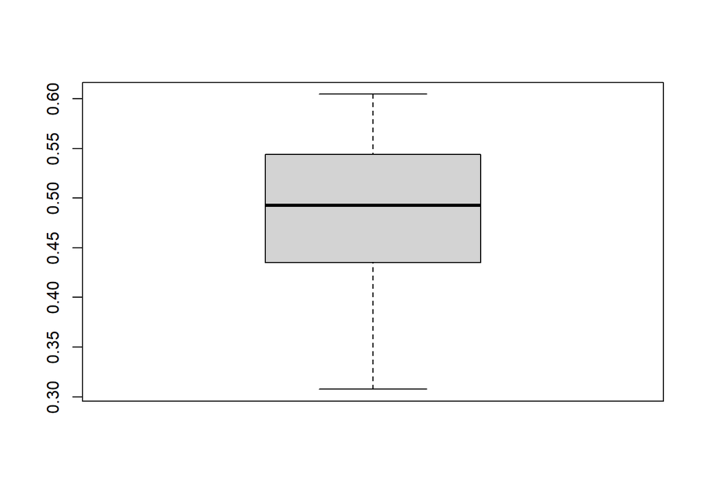

```r
boxplot(pwp_df_psb$pwp)
```

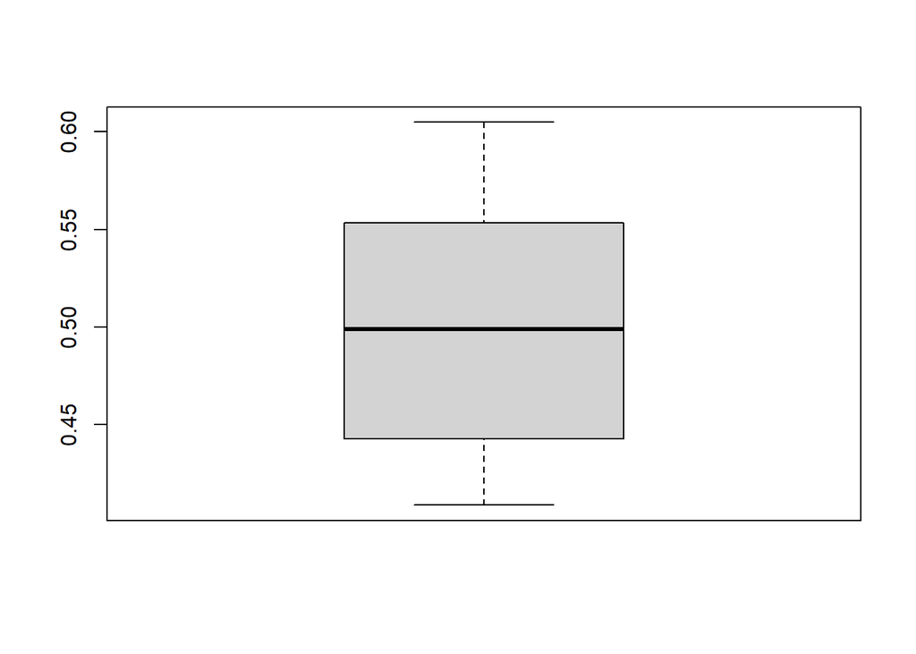

```r
boxplot(pwp_df_psb_active$pwp)
```

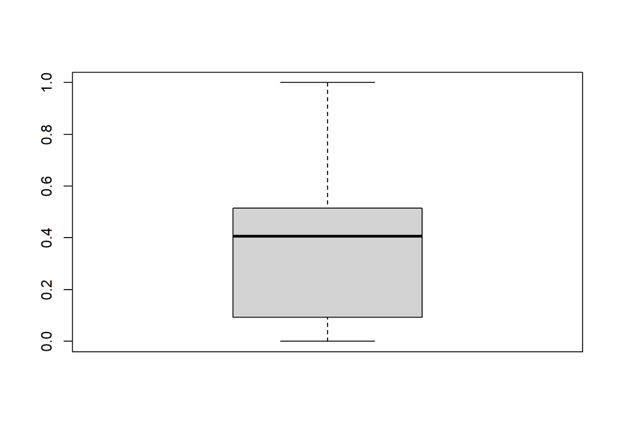

```r
boxplot(pwp_df_whole$pwp)
```

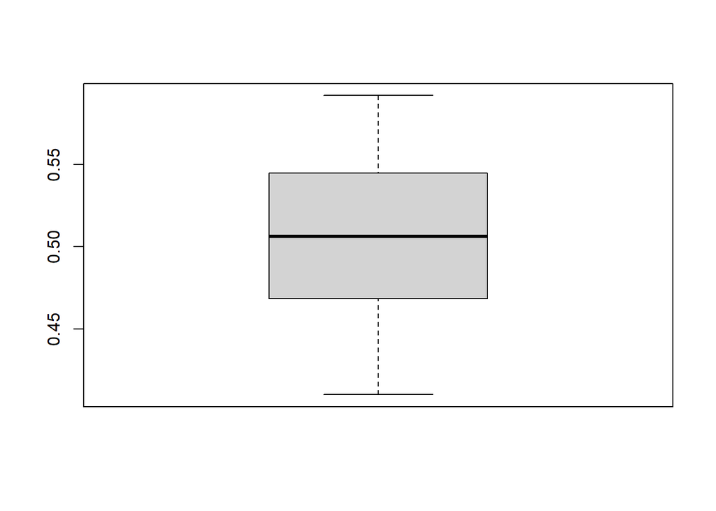

```r
boxplot(pwp_df_whole_active$pwp)
```

Actual Win Percentage

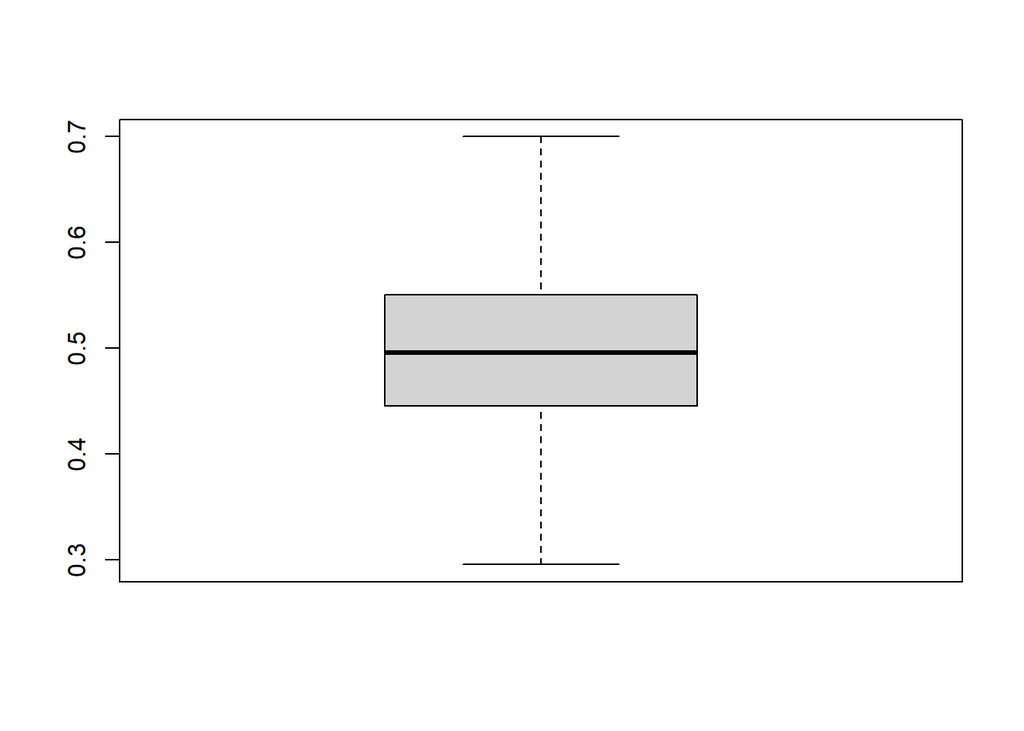

```r
boxplot(pwp_df_psb$actual_wp)
```

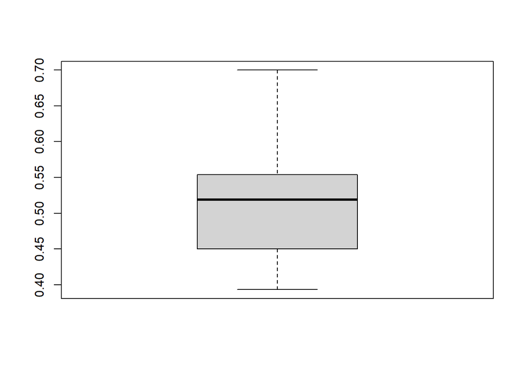

```r
boxplot(pwp_df_psb_active$actual_wp)
```

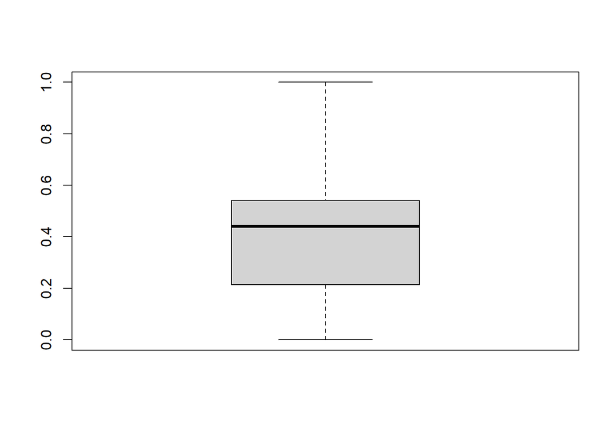

```r
boxplot(pwp_df_whole$actual_wp)
```

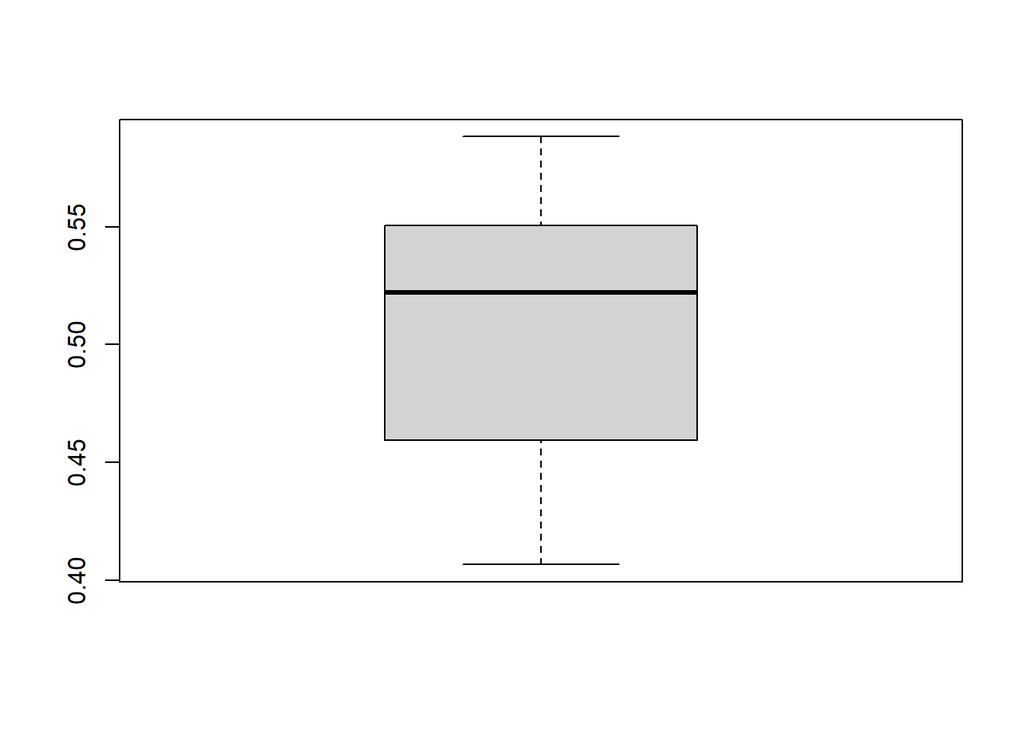

```r
boxplot(pwp_df_whole_active$actual_wp)
```

Errors

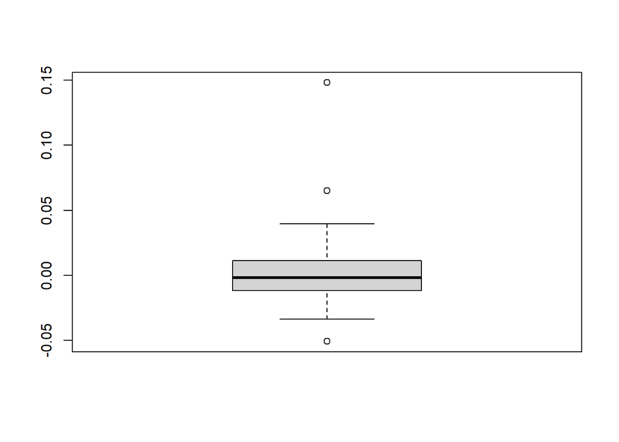

```r
boxplot(pwp_df_psb$error)
```

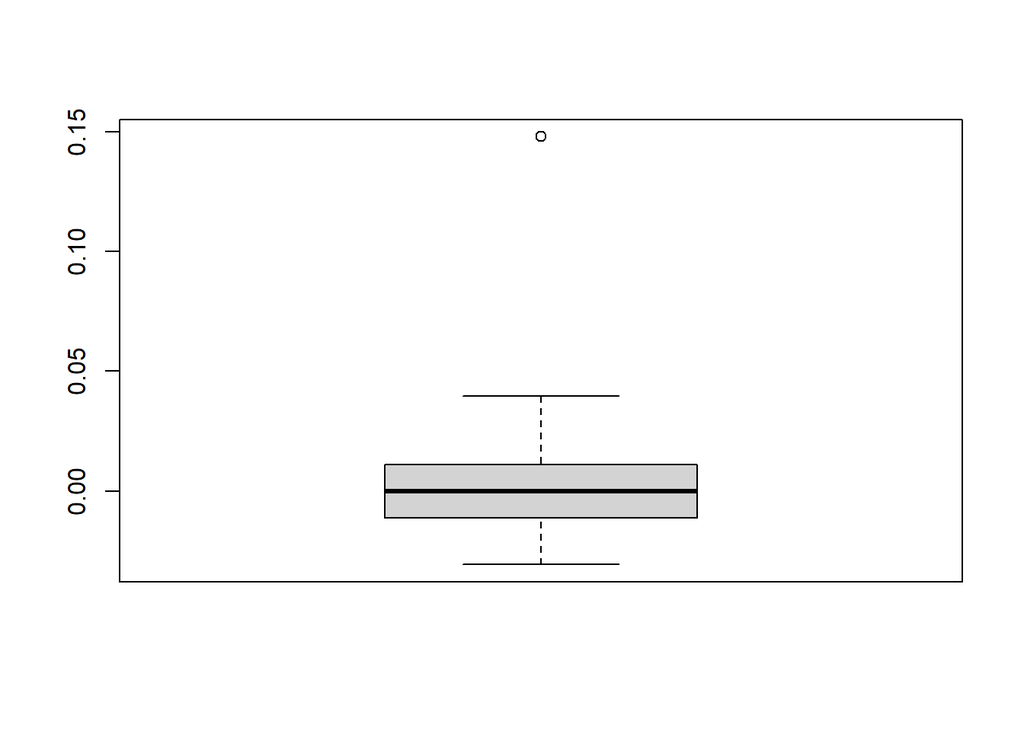

```r
boxplot(pwp_df_psb_active$error)
```

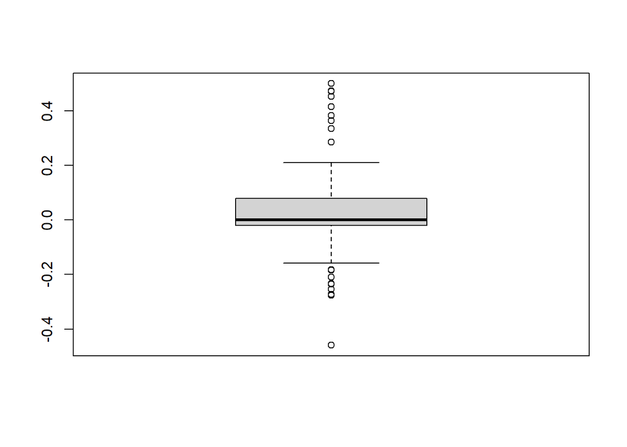

```r
boxplot(pwp_df_whole$error)
```

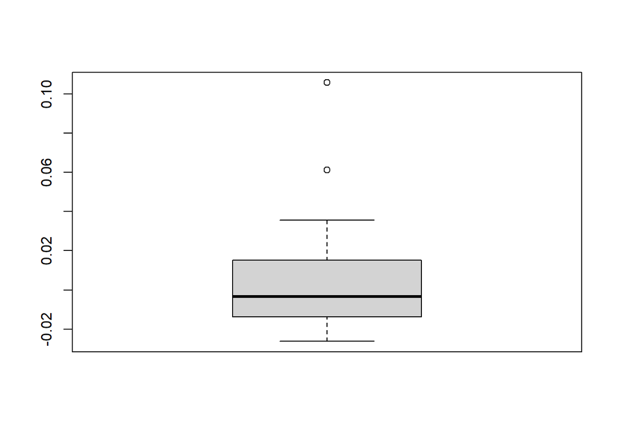

```r
boxplot(pwp_df_whole_active$error)
```

#Means and SD of the error

```r
#print mean and standard deviation of the errors
mean(pwp_df_whole$error)
```

```
## [1] 0.04067004
```

```r
sd(pwp_df_whole$error)
```

```
## [1] 0.1580575
```

```r
#print mean and standard deviation of the errors
mean(pwp_df_whole_active$error)
```

```
## [1] 0.00394693
```

```r
sd(pwp_df_whole_active$error)
```

```
## [1] 0.02652678
```

```r
#print mean and standard deviation of the errors
mean(pwp_df_psb$error)
```

```
## [1] 0.003234828
```

```r
sd(pwp_df_psb$error)
```

```
## [1] 0.03119961
```

```r
#print mean and standard deviation of the errors
mean(pwp_df_psb_active$error)
```

```
## [1] 0.005336013
```

```r
sd(pwp_df_psb_active$error)
```

```
## [1] 0.03166807
```

#Means and SD of the PWP

```r
#print mean and standard deviation of the pwps
mean(pwp_df_whole$pwp)
```

```
## [1] 0.3523597
```

```r
sd(pwp_df_whole$pwp)
```

```
## [1] 0.2644451
```

```r
#print mean and standard deviation of the pwps
mean(pwp_df_whole_active$pwp)
```

```
## [1] 0.5032722
```

```r
sd(pwp_df_whole_active$pwp)
```

```
## [1] 0.05086752
```

```r
#print mean and standard deviation of the pwps
mean(pwp_df_psb$pwp)
```

```
## [1] 0.4909958
```

```r
sd(pwp_df_psb$pwp)
```

```
## [1] 0.06796556
```

```r
#print mean and standard deviation of the pwps
mean(pwp_df_psb_active$pwp)
```

```
## [1] 0.5003597
```

```r
sd(pwp_df_psb_active$pwp)
```

```
## [1] 0.05994805
```

#Finding Our Answer

#Detroit Lions info

```r
pwp_df_whole[(pwp_df_whole$team_name == "Detroit Lions"),]
```

```
##       team_name pts_scored pts_allowed total_wins total_losses total_games
## 8 Detroit Lions      24746       26310        557          698        1255
##   actual_wp          pwp       error
## 8 0.4438247 0.466058.... -0.02223343
```

```r
pwp_df_whole_active[(pwp_df_whole_active$team_name == "Detroit Lions"),]
```

```
##       team_name pts_scored pts_allowed total_wins total_losses total_games
## 5 Detroit Lions      24746       26310        557          698        1255
##   actual_wp          pwp       error
## 5 0.4438247 0.465105.... -0.02128038
```

```r
pwp_df_psb[(pwp_df_psb$team_name == "Detroit Lions"),]
```

```
##        team_name pts_scored pts_allowed total_wins total_losses total_games
## 34 Detroit Lions      13085       14835        269          399         668
##    actual_wp          pwp       error
## 34 0.4026946 0.426017.... -0.02332339
```

```r
pwp_df_psb_active[(pwp_df_psb_active$team_name == "Detroit Lions"),]
```

```
##        team_name pts_scored pts_allowed total_wins total_losses total_games
## 26 Detroit Lions      13085       14835        269          399         668
##    actual_wp          pwp       error
## 26 0.4026946 0.426017.... -0.02332339
```

Is the NFL team with the worst performance history the Detroit Lions?

```r
#Among All Teams
pwp_df_whole[which(pwp_df_whole$actual_wp == min(pwp_df_whole$actual_wp), arr.ind = TRUE),]
```

```
##                           team_name pts_scored pts_allowed total_wins
## 129                     Fort Porter          0          66          0
## 130                 Brooklyn Tigers         62         145          0
## 131             Louisville Colonels          0         108          0
## 132          Chi/Pit Cards/Steelers         95         274          0
## 133                    Logan Square          9          14          0
## 134              Cleveland Panthers         14          40          0
## 135                   Muncie Flyers          0          73          0
## 136                Tonawanda Kardex          0          45          0
## 137 Washington and Jeffe Collegians          7          48          0
## 138             McKeesport Olympics          7          28          0
## 139       Moline Universal Tractors          0          53          0
## 140               Kewanee Walworths          7          25          0
## 141                Pitcairn Quakers          0          48          0
## 142                 St. Paul Ideals          0          48          0
```

[output cut: 33 more lines]

```r
#Among All Active Teams
pwp_df_whole_active[which(pwp_df_whole_active$actual_wp == min(pwp_df_whole_active$actual_wp), arr.ind = TRUE),]
```

```
##               team_name pts_scored pts_allowed total_wins total_losses
## 18 Tampa Bay Buccaneers      13965       16051        303          442
##    total_games actual_wp          pwp       error
## 18         745 0.4067114 0.421263.... -0.01455211
```

```r
#Among All Teams Post Super Bowl
pwp_df_psb[which(pwp_df_psb$actual_wp == min(pwp_df_psb$actual_wp), arr.ind = TRUE),]
```

```
##            team_name pts_scored pts_allowed total_wins total_losses total_games
## 25 Phoenix Cardinals       1194        1560         21           50          71
##    actual_wp          pwp       error
## 25 0.2957746 0.346373.... -0.05059851
```

```r
#Among All Active Teams Post Super Bowl
pwp_df_psb_active[which(pwp_df_psb_active$actual_wp == min(pwp_df_psb_active$actual_wp), arr.ind = TRUE),]
```

```
##               team_name pts_scored pts_allowed total_wins total_losses
## 14 Tampa Bay Buccaneers      10415       12162        217          335
##    total_games actual_wp          pwp       error
## 14         552 0.3931159 0.408954.... -0.01583846
```

Is the Unluckiest NFL team in history the Detroit Lions?

```r
#Among All Teams
pwp_df_whole[which(pwp_df_whole$error == min(pwp_df_whole$error), arr.ind = TRUE),]
```

```
##          team_name pts_scored pts_allowed total_wins total_losses total_games
## 151 Pullman Thorns         13          14          0            1           1
##     actual_wp          pwp      error
## 151         0 0.458985.... -0.4589856
```

```r
#Among All Active Teams
pwp_df_whole_active[which(pwp_df_whole_active$error == min(pwp_df_whole_active$error), arr.ind = TRUE),]
```

```
##           team_name pts_scored pts_allowed total_wins total_losses total_games
## 24 Baltimore Ravens      10016        8510        254          195         449
##    actual_wp          pwp       error
## 24 0.5657016 0.591872.... -0.02617083
```

```r
#Among All Teams Post Super Bowl
pwp_df_psb[which(pwp_df_psb$error == min(pwp_df_psb$error), arr.ind = TRUE),]
```

```
##            team_name pts_scored pts_allowed total_wins total_losses total_games
## 25 Phoenix Cardinals       1194        1560         21           50          71
##    actual_wp          pwp       error
## 25 0.2957746 0.346373.... -0.05059851
```

```r
#Among All Active Teams Post Super Bowl
pwp_df_psb_active[which(pwp_df_psb_active$error == min(pwp_df_psb_active$error), arr.ind = TRUE),]
```

```
##           team_name pts_scored pts_allowed total_wins total_losses total_games
## 23 Baltimore Ravens       7147        6201        178          144         322
##    actual_wp          pwp       error
## 23  0.552795 0.583512.... -0.03071701
```

Is the Detroit Lions’ actual win percentage significantly lower than the rest of the NFL teams?

```r
(mean(pwp_df_whole$actual_wp) - pwp_df_whole[(pwp_df_whole$team_name == "Detroit Lions"),7])/sd(pwp_df_whole$actual_wp)
```

```
## [1] -0.2069099
```

```r
(mean(pwp_df_whole_active$actual_wp) - pwp_df_whole_active[(pwp_df_whole_active$team_name == "Detroit Lions"),7])/sd(pwp_df_whole_active$actual_wp)
```

```
## [1] 1.186591
```

```r
(mean(pwp_df_psb$actual_wp) - pwp_df_psb[(pwp_df_psb$team_name == "Detroit Lions"),7])/sd(pwp_df_psb$actual_wp)
```

```
## [1] 1.172654
```

```r
(mean(pwp_df_psb_active$actual_wp) - pwp_df_psb_active[(pwp_df_psb_active$team_name == "Detroit Lions"),7])/sd(pwp_df_psb_active$actual_wp)
```

```
## [1] 1.502957
```

Is the Detroit Lions’ Pythagorean win percentage significantly lower than the rest of the NFL teams?

```r
(mean(pwp_df_whole$pwp) - pwp_df_whole[(pwp_df_whole$team_name == "Detroit Lions"),8])/sd(pwp_df_whole$pwp)
```

```
## [1] -0.429951
```

```r
(mean(pwp_df_whole_active$pwp) - pwp_df_whole_active[(pwp_df_whole_active$team_name == "Detroit Lions"),8])/sd(pwp_df_whole_active$pwp)
```

```
## [1] 0.7503233
```

```r
(mean(pwp_df_psb$pwp) - pwp_df_psb[(pwp_df_psb$team_name == "Detroit Lions"),8])/sd(pwp_df_psb$pwp)
```

```
## [1] 0.9560404
```

```r
(mean(pwp_df_psb_active$pwp) - pwp_df_psb_active[(pwp_df_psb_active$team_name == "Detroit Lions"),8])/sd(pwp_df_psb_active$pwp)
```

```
## [1] 1.240102
```

Is the Detroit Lions’ actual win percentage significantly less than their Pythagorean win percentage?

```r
(mean(pwp_df_whole$error) - pwp_df_whole[(pwp_df_whole$team_name == "Detroit Lions"),9])/sd(pwp_df_whole$error)
```

```
## [1] 0.3979784
```

```r
(mean(pwp_df_whole_active$error) - pwp_df_whole_active[(pwp_df_whole_active$team_name == "Detroit Lions"),9])/sd(pwp_df_whole_active$error)
```

```
## [1] 0.9510129
```

```r
(mean(pwp_df_psb$error) - pwp_df_psb[(pwp_df_psb$team_name == "Detroit Lions"),9])/sd(pwp_df_psb$error)
```

```
## [1] 0.8512355
```

```r
(mean(pwp_df_psb_active$error) - pwp_df_psb_active[(pwp_df_psb_active$team_name == "Detroit Lions"),9])/sd(pwp_df_psb_active$error)
```

```
## [1] 0.9049936
```